# Concurrent areas problem

Derek Corcoran

2022-05-15

## Load the packages

```r
library(sf)
library(dplyr)
library(terra)
library(ggplot2)
library(tidyr)
library(patchwork)
```

## The problem

In order to state the problem we will use a variation of the example used in the [SF website](https://r-spatial.github.io/sf/articles/sf3.html#geometrical-operations)

```r
b0 = st_polygon(list(rbind(c(-1,-1), c(1,-1), c(1,1), c(-1,1), c(-1,-1))))
b1 = b0 + 2
b2 = b0 + c(-0.2, 2)
x = st_sfc(b0, b1, b2)

red_sf <- x %>% st_as_sf() %>% mutate(Red = 1)

red_sf$NameRed <- c("b0", "b1", "b2")
a0 = b0 * 0.8
a1 = a0 * 0.5 + c(2, 0.7)
a2 = a0 + 0.5
a3 = b0 * 0.5 + c(2, -0.5)
y = st_sfc(a1,a2,a3)
green_sf <- y %>% st_as_sf() %>% mutate(Green = 1)

green_sf$NameGreen <- c("a1", "a2", "a3")
```

This creates 2 groups of polygons that we can see here:

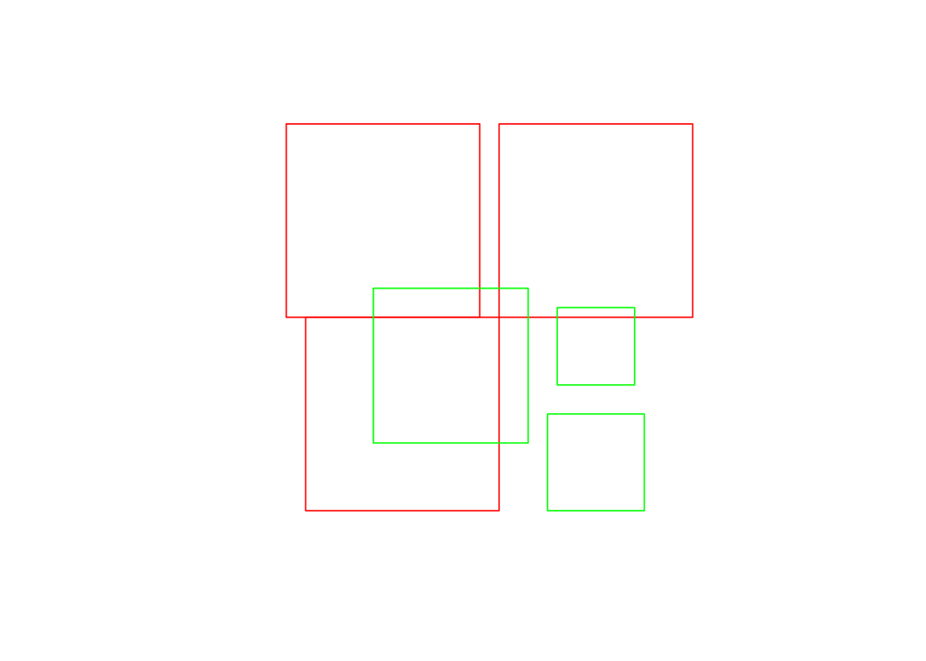

As it can be seen there is some intersection between both groups of polygons, that compromises the 3 polygons in the red group, and 2 of the polygons in the green group. Since the solution is going to be later used for several groups each with over 300.000 polygons, the idea is that the solution generates a pre calculated sf, where all the polygons that are not intersecting with the other group are left us such.

## Expected results

### Total area

This should always get you:

```r
st_area(st_union(st_union(red_sf), st_union(green_sf)))
```

```
## [1] 14.01
```

Which is the area of the following polygon:

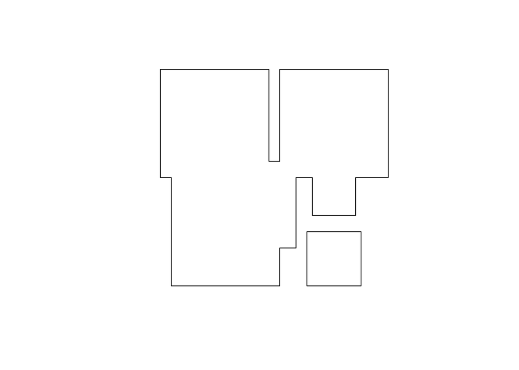

### Red area

This should always get you:

```r
st_area(st_union(red_sf))
```

```
## [1] 12
```

Which is the area of the following polygon:

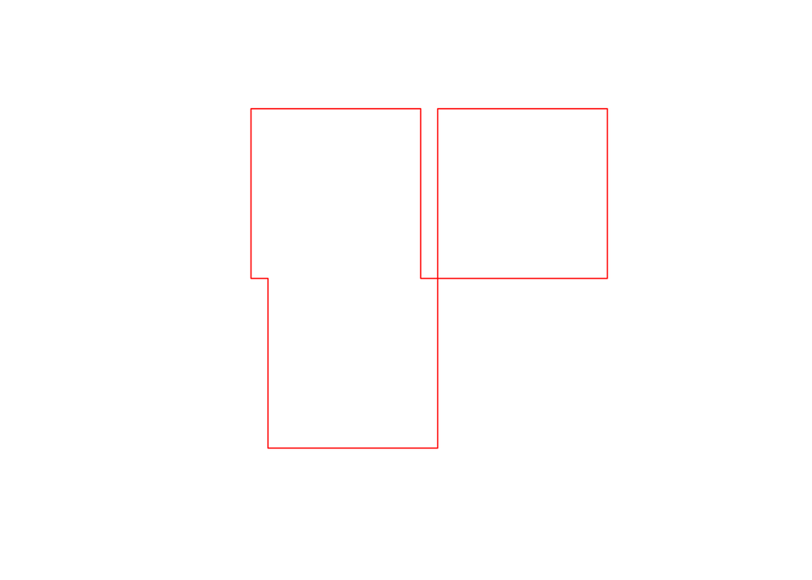

### Green area

This should always get you:

```r
st_area(st_union(green_sf))
```

```
## [1] 4.2
```

Which is the area of the following polygon:

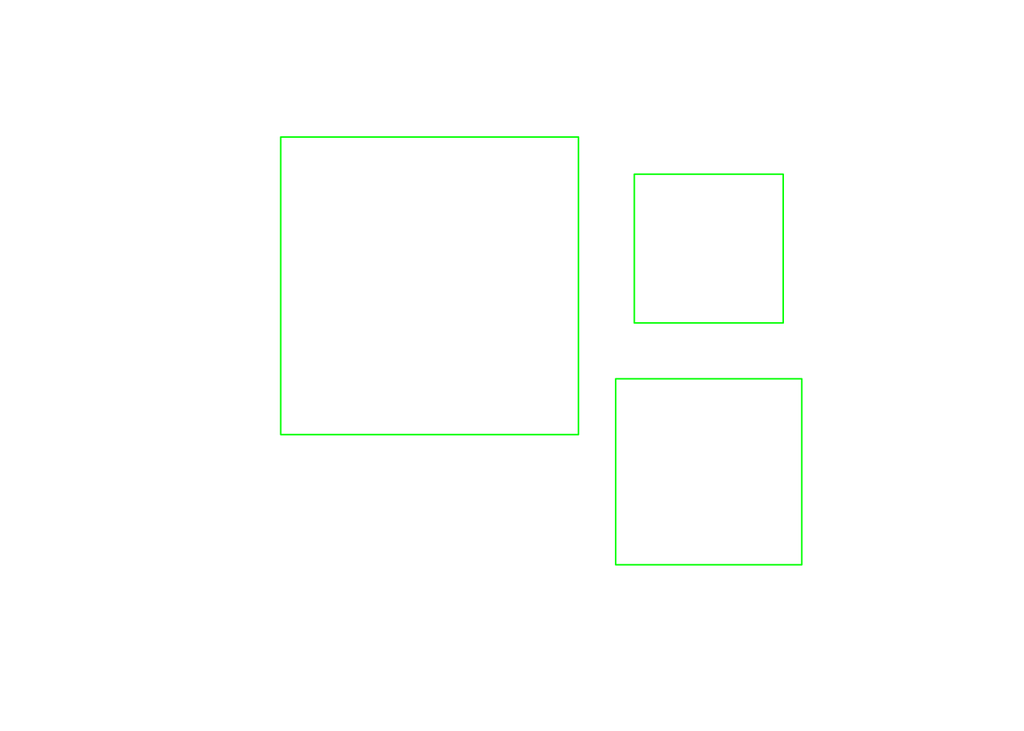

# With SF package

## Tests

### Intersection

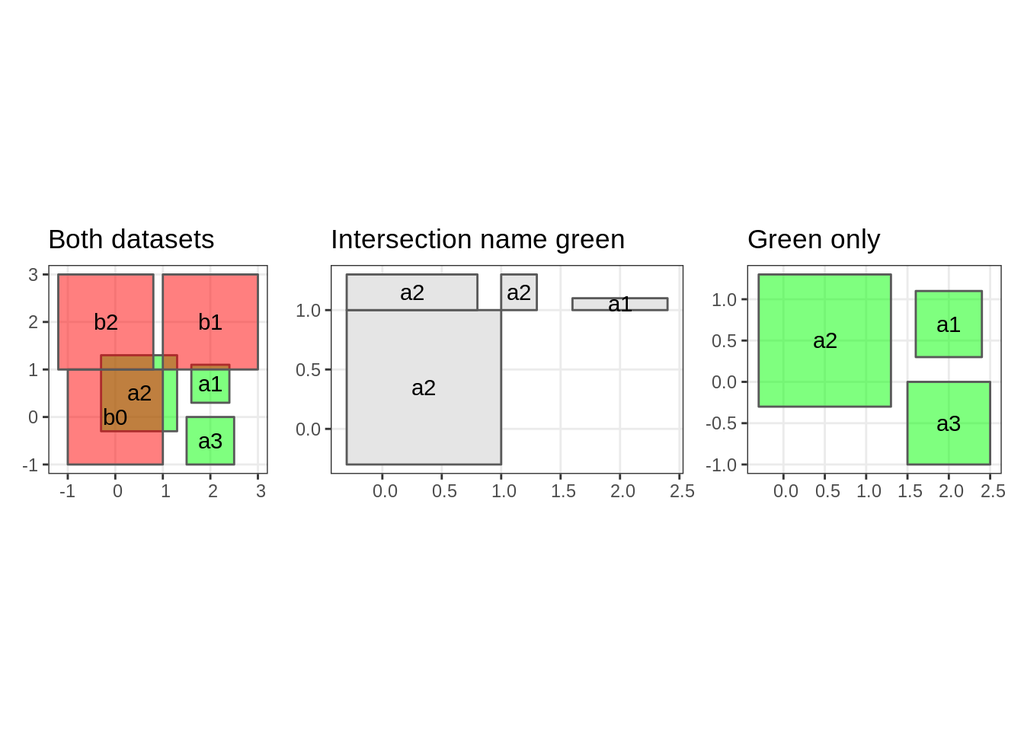

```r
P0 <- ggplot() + geom_sf(data = green_sf, alpha = 0.5, fill = "green") + geom_sf(data = red_sf, alpha = 0.5, fill = "red") + theme_bw()  + ggtitle("Both datasets") + labs(x = NULL, y = NULL) + geom_sf_text(data = green_sf, aes(label = NameGreen)) + geom_sf_text(data = red_sf, aes(label = NameRed))

P1 <- ggplot(st_intersection(green_sf, red_sf)) + geom_sf() + theme_bw() + geom_sf_text(aes(label = NameGreen)) + ggtitle("Intersection name green") + labs(x = NULL, y = NULL)

P2 <- ggplot(green_sf) + geom_sf(alpha = 0.5, fill = "green") + theme_bw() + geom_sf_text(aes(label = NameGreen)) + ggtitle("Green only") + labs(x = NULL, y = NULL)



P0  + P1 + P2
```

### Difference

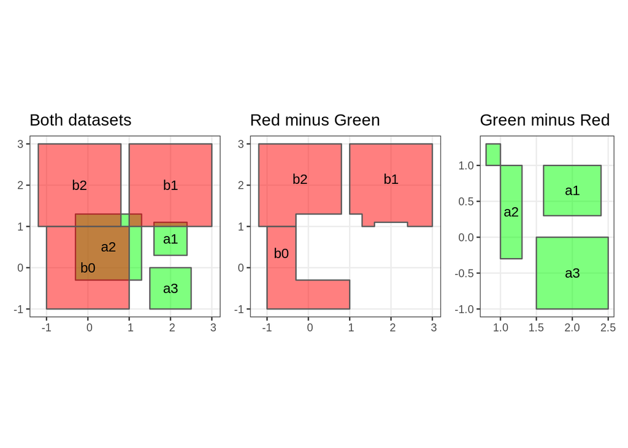

```r
P5 <- ggplot(st_intersection(red_sf, st_difference(st_union(red_sf), st_union(green_sf)))) + geom_sf(fill = "red", alpha = 0.5) + geom_sf_text(aes(label = NameRed)) + theme_bw() +  ggtitle("Red minus Green") + labs(x = NULL, y = NULL)

P6 <- ggplot(st_intersection(green_sf, st_difference(st_union(green_sf), st_union(red_sf)))) + geom_sf(fill = "green", alpha = 0.5)  + geom_sf_text(aes(label = NameGreen))+ theme_bw() + ggtitle("Green minus Red") + labs(x = NULL, y = NULL)

P0  + P5 + P6
```

### All Together

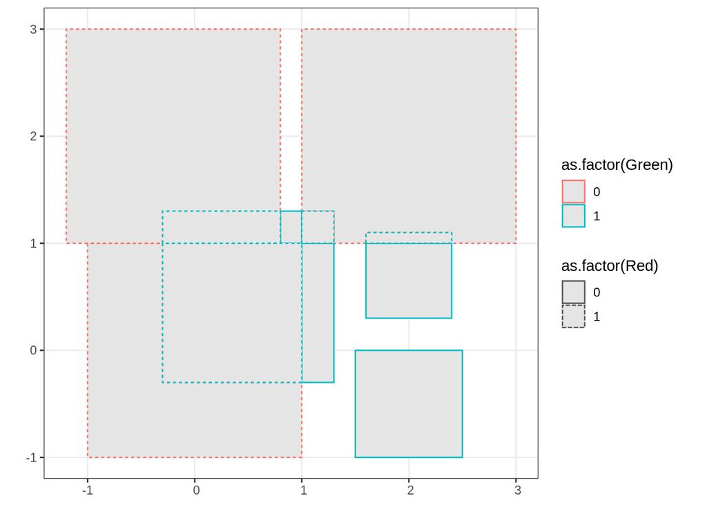

```r
Intersection <- st_intersection(green_sf, red_sf)
OnlyRed <- st_intersection(red_sf, st_difference(st_union(red_sf), st_union(green_sf)))
OnlyGreen <- st_intersection(green_sf, st_difference(st_union(green_sf), st_union(red_sf)))

All <- list(Intersection, OnlyRed, OnlyGreen) %>%
  purrr::reduce(bind_rows) %>%
  tidyr::replace_na(list(Green = 0, Red = 0))

All$Area <- st_area(All)


ggplot(All) + geom_sf(aes(color = as.factor(Green), lty = as.factor(Red))) + theme_bw()
```

## Final test

Total Area:

```r
All$Area %>% sum()
```

```
## [1] 14.01
```

Area Green:

```r
All %>% dplyr::filter(Green == 1) %>% pull(Area) %>% sum()
```

```
## [1] 4.2
```

Area Red:

```r
All %>% dplyr::filter(Red == 1) %>% pull(Area) %>% sum()
```

```
## [1] 12
```

# With terra package

```r
red_vect <- red_sf %>% vect()
green_vect <- green_sf %>% vect()

All_Terra <- terra::union(red_vect, green_vect)

All_Terra$Area <- All_Terra %>% terra::expanse()
```

## Tests

Total Area:

```r
sum(All_Terra$Area)
```

```
## [1] 14.01
```

Green Area:

```r
sum(All_Terra[All_Terra$Green == 1,]$Area)
```

```
## [1] 4.2
```

Red Area:

```r
sum(All_Terra[All_Terra$Red == 1,]$Area)
```

```
## [1] 12
```